# Score report of examn 1 - 2024-I

###### This report is exclusive for professor "Dr. Name" it cointains information about the Examn 1 and students id.

###### Author: Juan Diego Zapata Diaz.

# Score distribution: total

The total distribution shows high dispersion of scores. While the 50% of scores lies between 9 and 15.8, the median is 11. There is a clear positive asymmetry as we se the median close to the first quartile.

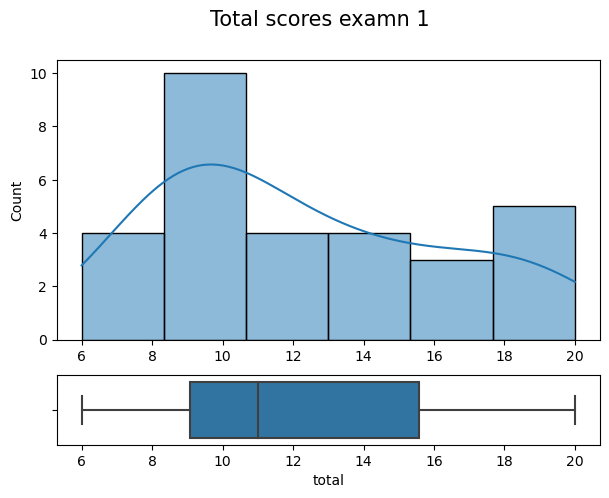

# Score distribution: Conceptual questions

There is more concensus in the scores of conceptual questions as usual in this section. However looking at the boxplot we can see that the positive asymmetry is still showing up in this section.

[figure not shown]

# Score distribution: Numerical questions

As we can se in the ditribution it is markedly bimodal. This indicates that we have two groups of students clearly separate by the grades in this examn. The positive asymmetry have been generated by the numerical questions in which the two groups have diferenciated a lot.

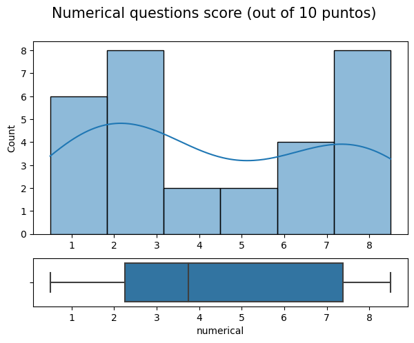

# Interactive plot of the *score space*

Each of the points is one student (when selected the id is shown). The concept of the *score space* is that we can see this plot as a space that discribes the class scores. In general, people who have better score in the conceptual sections have also good grading in the numerical section. Students can see where they locate in the *score space* and focus on the sections that allow them to be in a better section of this space

[interactive chart not shown]